# Aside

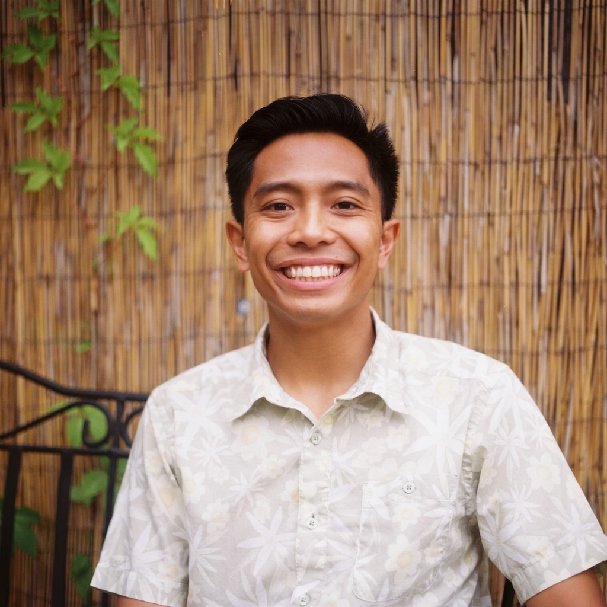

## JP FLORES, PHD

- he/him
- jpflores013@gmail.com
- jpflores_31
- github.com/jpflores-13
- jpflores.rbind.io
- linkedin.com/in/john-patrick-flores

## Skills

R

Python

Bash

CSS

HTML

## Featured Awards & Accolades

- - [**Howard Hughes Medical Institute (HHMI) Gilliam Fellows Program (2024)**](https://www.hhmi.org/news/hhmi-names-50-gilliam-fellows-milestone-year)
- [Public Voices Fellow on Technology in the Public Interest - The OpEd Project & MacArthur Foundation](https://www.macfound.org/press/grantee-news/new-voices-shaping-narrative-of-technology-for-the-public-interest) (2025)
- [American Society of Human Genetics Human Genetics Scholar (2024)](https://www.ashg.org/membership/awards/hgsi/)
- [Occidental’s 18 Young Scientists to Watch](https://www.oxy.edu/magazine/issues/spring-2023/18-young-scientists-watch) (2023)
- [**National Science Foundation Graduate Research Fellow**](https://www.oxy.edu/academics/student-success/national-international-fellowships/fellowships-stories/john-patrick) **(2021)**
- [Spotify Next Wave Award Winner](https://podcasters.spotify.com/resources/news) (2021)

## More info

See full CV at [jpflores-13.github.io/my-cv/](https://jpflores-13.github.io/my-cv/cv.html)

## Disclaimer

Made w/ [**pagedown**](https://github.com/rstudio/pagedown).

Source code: github.com/jpflores-13/my-cv.

Last updated on 2026-06-22.

# Main

## JP Flores

Genomicist interested in genome organization and function. PhD from University of North Carolina at Chapel Hill with a Graduate Certificate in Innovation for the Public Good. Fulbright Scholar in Milan, Italy in the lab of Dr. Michele Gabriele. Incoming HHMI Gilliam Postdoctoral Fellow at Case Western Reserve University in the lab of Dr. Marissa Scavuzzo. Co-founder of Science For Good, a nonprofit focused on strengthening public trust in science through community engagement. Passionate about advancing DEIA, science policy, and accessible science communication.

## Education

### PhD Candidate, Bioinformatics & Computational Biology

UNC Chapel Hill

Chapel Hill, NC

2025 - 2021

- Graduate Certificate in Innovation for the Public Good

### BA, Cellular & Molecular Biology (Public Health Minor)

Occidental College

Los Angeles, CA

2021 - 2017

## Research & Professional Experience

### Graduate Research Assistant

[Phanstiel Lab](http://phanstiel-lab.med.unc.edu/) (UNC-CH School of Medicine)

Chapel Hill, NC

2025 - 2022

- Developing and applying software in R, performing microscropy (DNA FISH) and -omics techniques (Hi-C, RNA-seq, ATAC-seq, CUT&RUN/ChIP-seq) to investigate the role of 3D chromatin structure in response to environmental stress
- Oral Defense is publicly available [here](https://www.youtube.com/watch?v=bnTBmrF8kso)

### Co-Founder

[Science For Good](https://sciforgood.org/)

N/A

2025

- Launched Science For Good (Sister Org: Stand Up for Science), a nonprofit organization that empowers researchers to engage with communities, policymakers, and the public through creative science communication and advocacy.

### Science Policy Intern

National Institutes of Health (NIH) Office of the Director

Bethesda, MD

2024

- Assist in developing a public vision and framework for including patient and community voices in the design and conduct of NIH-funded clinical research. Help plan public consultations to develop recommendations regarding engagement methods for research employing novel technologies and will be prototyping equitable and inclusive approaches for patient and community engagement. Work can be found [here](https://osp.od.nih.gov/wp-content/uploads/2025/12/NExTRACs-ENGAGE-Report_FINAL.pdf).

## Featured Talks

### [Plenary Session: Scientist Network for Advancing Policy (SNAP): Building a New Generation of Scientists Who Lead in Policy and Civic Engagement](https://www.youtube.com/watch?v=QuLj_1V2KeY)

American Association for the Advancement of Science (AAAS) Annual Meeting Science at Scale

Phoenix, AZ

2026

### Hyperosmotic stress induces complete rewiring of chromatin interactions

UCLA Emerging Genomics Scientists Symposium

Los Angeles, CA

2025